# Mechanisms in Björn’s model

# 1 Monoculture biomass

## 1.1 Monoculture biomass over time

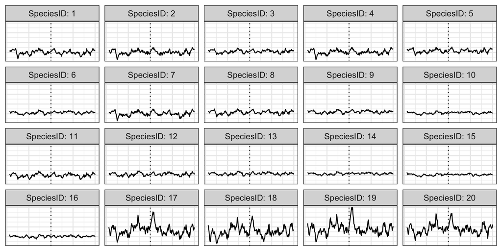

```r
monocultures <- bjoern %>%
    filter(Ninitial == 1,
           SpeciesID %in% seq(1, 20))

ggplot(monocultures) +
    geom_line(aes(x = Year,
                  y = Biomass)) +
    geom_vline(xintercept = 100, linetype = 3) +
    facet_wrap(facets = vars(SpeciesID),
               ncol = 5,
               labeller = label_both) +
    theme_bw()
```

## 1.2 Monoculture biomass vs. trait values

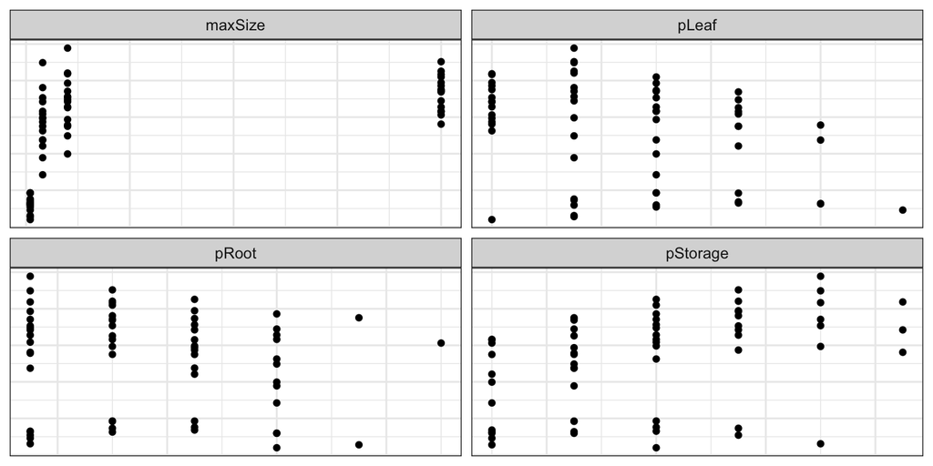

```r
bjoern.monocultures <- bjoern %>%
    filter(Ninitial == 1,
           Year %in% seq(180, 200)) %>%
    group_by_at(vars(c("SpeciesID", trait.list))) %>%
    summarise(monoculture.biomass = mean(Biomass)) %>%
    ungroup() %>%
    pivot_longer(c(-SpeciesID, -monoculture.biomass),
                 names_to = "trait",
                 values_to = "trait.value")

ggplot(bjoern.monocultures) +
    geom_point(aes(x = trait.value,
                   y = monoculture.biomass)) +
    facet_wrap(facets = vars(trait),
               ncol = 2,
               scales = "free") +
    labs(x = "Trait value",
         y = "Monoculture biomass") +
    theme_bw()
```

The only consistent relationship between the traits an monoculture biomass seems to be a saturating curve for maxSize.

## 1.3 Monoculture biomass vs. traints in ternary relationships

To see if there are any relationships between the traits themselves in terms of the biomass they eventually produce, I now plot the four traits in ternary relationships.

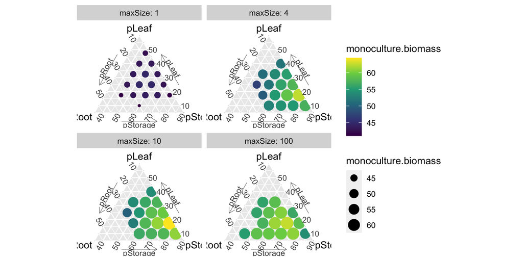

```r
bjoern.monocultures <- bjoern %>%
    filter(Ninitial == 1,
           Year %in% seq(180, 200)) %>%
    group_by_at(vars(c("SpeciesID", trait.list))) %>%
    summarise(monoculture.biomass = mean(Biomass))

ggtern::ggtern(data = bjoern.monocultures,
               mapping = aes(x = pRoot,
                             y = pLeaf,
                             z = pStorage,
                             color = monoculture.biomass,
                             size = monoculture.biomass)) +
    geom_point() +
    scale_color_viridis_c() +
    facet_wrap(vars(maxSize),
               ncol = 2,
               labeller = "label_both") +
    tern_limits(T = 0.6, L = 0.6, R = 0.9) +
    theme_showarrows()
```

Unfortunately, it doesn’t look like there are any other consisten relationships between the traits.

## 1.4 Variable importance through random forests of monoculture biomass

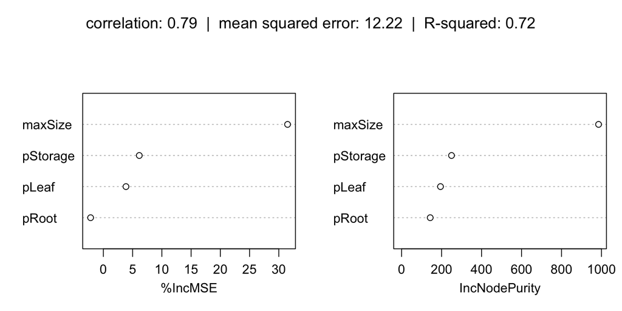

```r
monocultures <- bjoern %>%
    filter(Ninitial == 1,
           Year %in% seq(180, 200)) %>%
    group_by_at(vars(c("SpeciesID", trait.list))) %>%
    summarise(Biomass = mean(Biomass)) %>%
    ungroup()

monocultures <- monocultures %>%
    mutate(id = row_number()) %>%
    select(-SpeciesID)

train <- monocultures %>% sample_frac(.70)
test <- anti_join(monocultures, train, by = 'id')

train <- train %>% select(-id)
test <- test %>% select(-id)

rf.mono <- randomForest(data = as.data.frame(train),
                      Biomass ~ .,
                      importance = TRUE)

pred <- data.frame(pred = predict(rf.mono, test))
title = paste("correlation: ", round(cor(pred, test$Biomass)[[1]], 2),
              "  |  mean squared error: ", round(mean(rf.mono$mse), 2),
              "  |  R-squared: ", round(mean(rf.mono$rsq), 2),
              sep = "")

varImpPlot(rf.mono, main = title)
```

From this, we can see that maxSize is - confirming intuition - by far the most important predictor of monoculture biomass. However, given that the monoculture biomass should be entirely determined by the traits, it is worth noting that the random forest can only explain ~ 70% of the total variability in the biomass dataset. To compare this with the other models (e.g. TROLL, adam, lindsay, and PPA), the random forests can account for almost all of the variability in the biomass datasets.

# 2 Mixture biomass

## 2.1 Mixture biomass vs. traits

I now move on to the 32-species mixtures, showing as before how the average biomass depends on the traits in isolation.

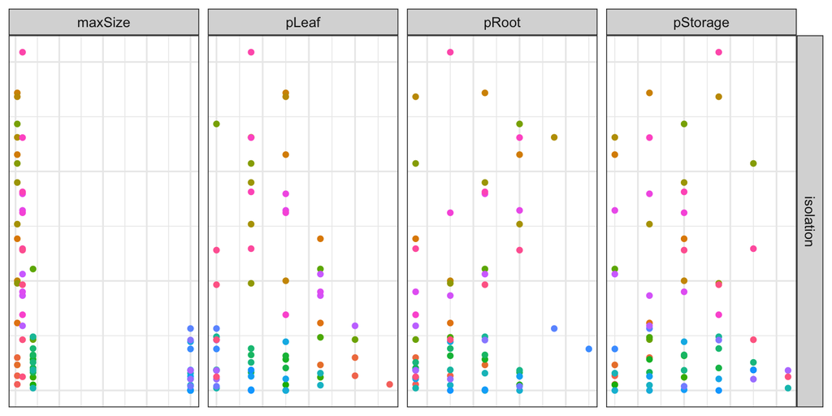

```r
bjoern.communities <- bjoern %>%
    filter(Ninitial == 32,
           Year %in% c(180, 200)) %>%
    group_by(Stage, SpeciesID, maxSize, pLeaf, pRoot, pStorage) %>%
    summarise(mean.biomass = mean(Biomass))

bjoern.communities <- bjoern.communities %>%
    pivot_longer(c(-Stage, -SpeciesID, -mean.biomass),
                 names_to = "trait",
                 values_to = "trait.value")

ggplot(bjoern.communities) +
    geom_point(aes(x = trait.value,
                   y = mean.biomass,
                   color = SpeciesID)) +
    facet_grid(cols = vars(trait),
               rows = vars(Stage),
               scales = "free") +
    labs(x = "Trait value",
         y = "Mean biomass") +
    theme_bw() +
    theme(legend.position = "none")
```

Here, the only consistent effect is that the species with very-high levels of `maxSize` so relatively poorly in mixture.

## 2.2 Variable importance of 32-species mixture biomasses

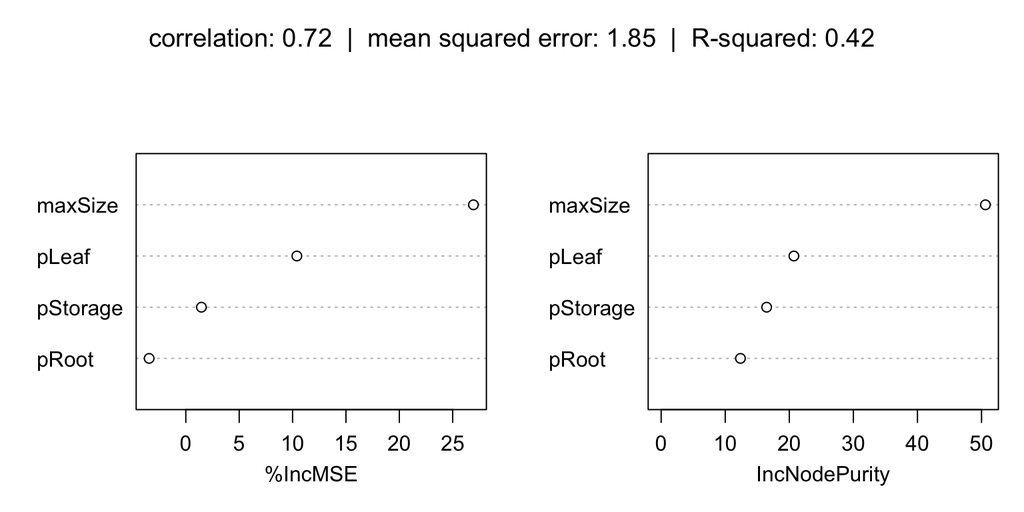

```r
mixtures.32 <- bjoern %>%
    filter(Ninitial == 32,
           Year %in% seq(180, 200)) %>%
    group_by_at(vars(c("SpeciesID", trait.list))) %>%
    summarise(Biomass = mean(Biomass))

mixtures.32 <- mixtures.32 %>%
    group_by_at(vars(c("SpeciesID", trait.list))) %>%
    summarise(Biomass = mean(Biomass)) %>%
    ungroup()

mixtures.32 <- mixtures.32 %>%
    mutate(id = row_number()) %>%
    select(-SpeciesID)

train <- mixtures.32 %>% sample_frac(.70)
test <- anti_join(mixtures.32, train, by = 'id')

train <- train %>% select(-id)
test <- test %>% select(-id)

rf.mixture.biomass <- randomForest(data = as.data.frame(train),
                                   Biomass ~ .,
                                   importance = TRUE)

pred <- data.frame(pred = predict(rf.mixture.biomass, test))
title = paste("correlation: ", round(cor(pred, test$Biomass)[[1]], 2),
              "  |  mean squared error: ", round(mean(rf.mixture.biomass$mse), 2),
              "  |  R-squared: ", round(mean(rf.mixture.biomass$rsq), 2),
              sep = "")

varImpPlot(rf.mixture.biomass, main = title)
```

Inside of mixture, the predictive ability of the random forest suffers considerably. It appears that the traits don’t change very much in their importance, but I hesitate to trust this output.

## 2.3 Ternary plots of 32-species mixutres

Plotting the same ternary plots for the mixtures, we see that smaller maxSize plants tend to perform better in mixture than their larger counterpoints.

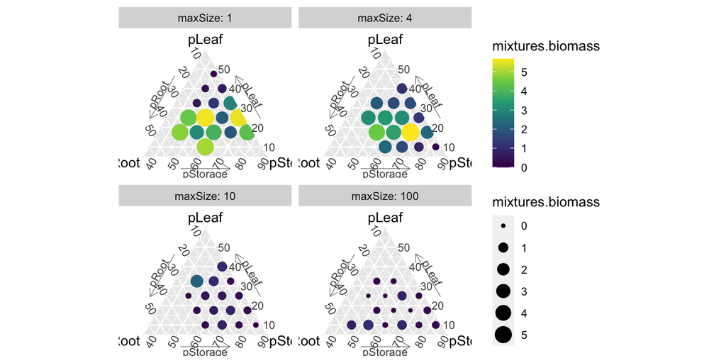

```r
mixtures.32 <- bjoern %>%
    filter(Ninitial == 32,
           Year %in% seq(180, 200)) %>%
    group_by_at(vars(c("SpeciesID", trait.list))) %>%
    summarise(mixtures.biomass = mean(Biomass))

ggtern::ggtern(data = mixtures.32,
               mapping = aes(x = pRoot,
                             y = pLeaf,
                             z = pStorage,
                             color = mixtures.biomass,
                             size = mixtures.biomass)) +
    geom_point() +
    scale_color_viridis_c() +
    facet_wrap(vars(maxSize),
               ncol = 2,
               labeller = "label_both") +
    tern_limits(T = 0.6, L = 0.6, R = 0.9) +
    theme_showarrows()
```

# 3 Time to extinction (TTE) in 32-species mixtures

## 3.1 32-species mixtures TTE vs. traits

Now I look at how the species’ extinctions vary with their traits.

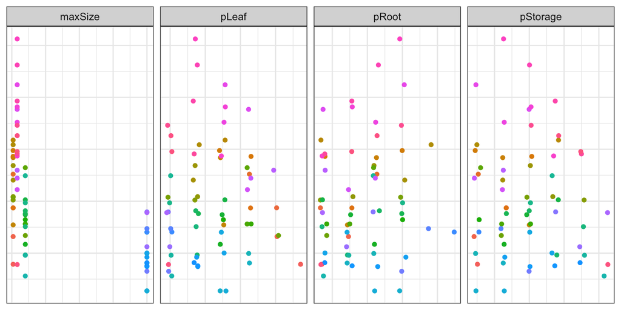

```r
bjoern.communities <- bjoern %>%
    filter(Ninitial == 32)

bjoern.communities <- bjoern.communities %>%
    group_by(SpeciesID, Rep) %>%
    arrange(Year) %>%
    mutate(isDead = (Biomass == 0)) %>%
    filter(isDead | (!isDead & Year == max(Year))) %>%
    filter(Year == first(Year))

bjoern.communities <- bjoern.communities %>%
    group_by_at(vars(c("SpeciesID", trait.list))) %>%
    summarise(Year = mean(Year))

bjoern.communities <- bjoern.communities %>%
    pivot_longer(c(-SpeciesID, -Year),
                 names_to = "trait",
                 values_to = "trait.value")

ggplot(bjoern.communities) +
    geom_jitter(aes(x = trait.value,
                    y = Year,
                    color = SpeciesID),
                show.legend = FALSE) +
    facet_grid(cols = vars(trait),
               scales = "free") +
    theme_bw()
```

Again, no consistent relationships, except that very large species do poorly.

## 3.2 Random forest of TTE

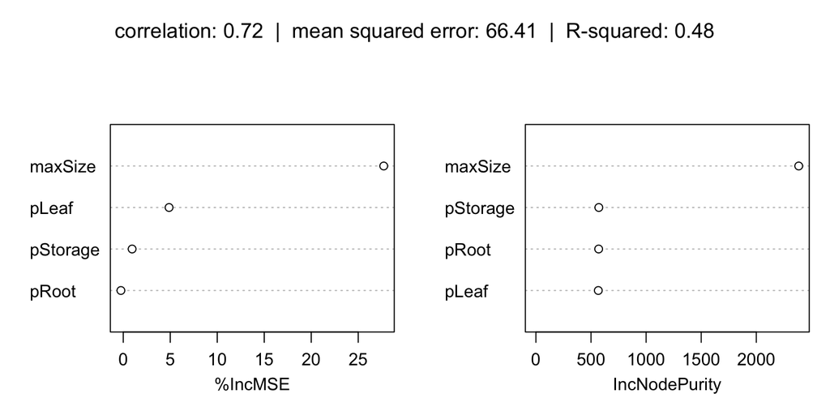

```r
mixtures.32 <- bjoern %>%
    filter(Ninitial == 32)

mixtures.32 <- mixtures.32 %>%
    group_by(SpeciesID, Rep) %>%
    arrange(Year) %>%
    mutate(isDead = (Biomass == 0)) %>%
    filter(isDead | (!isDead & Year == max(Year))) %>%
    filter(Year == first(Year))

mixtures.32 <- mixtures.32 %>%
    group_by_at(vars(c("SpeciesID", trait.list))) %>%
    summarise(Year = mean(Year)) %>%
    ungroup()

mixtures.32 <- mixtures.32 %>%
    mutate(id = row_number()) %>%
    select(-SpeciesID)

train <- mixtures.32 %>% sample_frac(.70)
test <- anti_join(mixtures.32, train, by = 'id')

train <- train %>% select(-id)
test <- test %>% select(-id)

rf.TTE <- randomForest(data = as.data.frame(train),
                       Year ~ .,
                       importance = TRUE)

pred <- data.frame(pred = predict(rf.TTE, test))
title = paste("correlation: ", round(cor(pred, test$Year)[[1]], 2),
              "  |  mean squared error: ", round(mean(rf.TTE$mse), 2),
              "  |  R-squared: ", round(mean(rf.TTE$rsq), 2),
              sep = "")

varImpPlot(rf.TTE, main = title)
```

The random forest does a very poor job in predicting extinction dynamics in the model, and cannot explain much of the relationship between the traits and the TTE.

# 4 32-species mixture biomass vs. monoculture biomass

Lastly, I look at the relationship between the species’ biomass in mixture and monoculture.

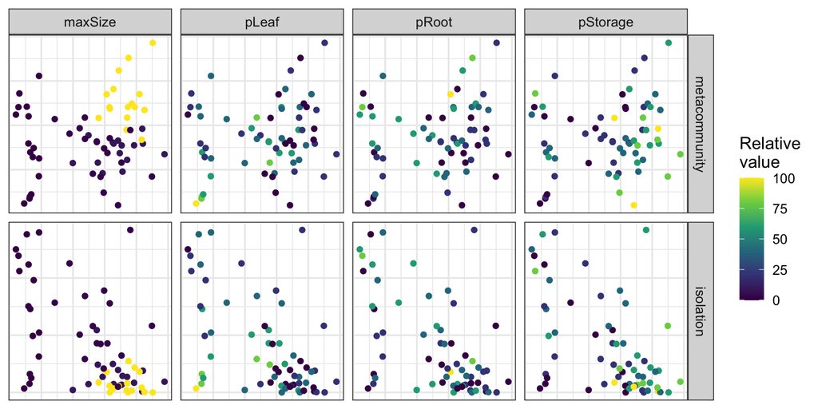

```r
bjoern.communities <- bjoern %>%
    filter(Ninitial == 32,
           Year %in% c(seq(80, 100),
                       seq(180, 200))) %>%
    group_by_at(vars(c("SpeciesID", "Stage", trait.list))) %>%
    summarise(mean.biomass = mean(Biomass))

bjoern.communities <- inner_join(bjoern.communities, bjoern.monocultures)

bjoern.communities <- bjoern.communities %>%
    ungroup() %>%
    pivot_longer(c(-Stage, -SpeciesID, -mean.biomass, -monoculture.biomass),
                 names_to = "trait",
                 values_to = "trait.value")

bjoern.communities <- bjoern.communities %>%
    group_by(trait) %>%
    mutate(trait.value =  scales::rescale(trait.value,
                                          to = c(0, 100)))

ggplot(bjoern.communities) +
    geom_point(aes(x = monoculture.biomass,
                   y = mean.biomass,
                   color = trait.value)) +
    facet_grid(cols = vars(trait),
               rows = vars(Stage),
               scales = "free") +
    scale_color_viridis_c() +
    labs(x = "Monoculture biomass",
         y = "Mixture biomass",
         color = "Relative\nvalue") +
    theme_bw()
```